# Identify and summarise indications among a drug cohort

# 2 Introduction

In this vignette, we demonstrate the functionality provided by the DrugUtilisation package to help understand the indications of patients in a drug cohort.

The DrugUtilisation package is designed to work with data in the OMOP CDM format, so our first step is to create a reference to the data using the DBI and CDMConnector packages.

```r
library(DrugUtilisation)

con <- DBI::dbConnect(duckdb::duckdb(), CDMConnector::eunomiaDir())

cdm <- CDMConnector::cdmFromCon(
  con = con,
  cdmSchema = "main",
  writeSchema = "main"
)
```

## 2.1 Create a drug utilisation cohort

We will use *acetaminophen* as our example drug. We’ll start by creating a cohort of acetaminophen users. Here we’ll include all acetaminophen records using a gap era of 7 days, but as we’ve seen in the previous vignette we could have also applied various other inclusion criteria.

```r
cdm <- generateIngredientCohortSet(
  cdm = cdm,
  name = "acetaminophen_users",
  ingredient = "acetaminophen",
  gapEra = 7
)
```

Note that `addIndication` works with a cohort as input, in this example we will use drug cohorts created with `generateDrugUtilisationCohortSet` but the input cohorts can be generated using many other ways.

## 2.2 Create a indication cohort

Next we will create a set of indication cohorts. In this case we will create cohorts for sinusitis and bronchitis using `CDMConnector::generateConceptCohortSet()`.

```r
indications <- list(
  sinusitis = c(257012, 4294548, 40481087),
  bronchitis = c(260139, 258780)
)

cdm <- CDMConnector::generateConceptCohortSet(
  cdm = cdm, name = "indications_cohort", indications, end = 0
)
cdm
```

# 3 Add indications with addIndication() function

Now that we have these two cohort tables, one with our drug cohort and another with our indications cohort, we can assess patient indications. For this we will specify a time window around the drug cohort start date for which we identify any intersection with the indication cohort. We can add this information as a new variable on our cohort table. This function will add a new column per window provided with the label of the indication.

```r
cdm[["acetaminophen_users"]] <- cdm[["acetaminophen_users"]] |>
  addIndication(
    indicationCohortName = "indications_cohort",
    indicationWindow = list(c(-30, 0)),
    indexDate = "cohort_start_date"
  )
cdm[["acetaminophen_users"]] |>
  dplyr::glimpse()
```

```
#> Rows: ??
#> Columns: 5
#> Database: DuckDB v1.3.1 [root@Darwin 24.5.0:R 4.4.1//private/var/folders/pl/k11lm9710hlgl02nvzx4z9wr0000gp/T/Rtmp5rcTya/file84b4177da363.duckdb]
#> $ cohort_definition_id <int> 1, 1, 1, 1, 1, 1, 1, 1, 1, 1, 1, 1, 1, 1, 1, 1, 1…
#> $ subject_id           <int> 2699, 2743, 2944, 1409, 4916, 3023, 4636, 4886, 4…
#> $ cohort_start_date    <date> 1971-10-15, 1961-08-31, 1965-12-01, 1931-10-14, …
#> $ cohort_end_date      <date> 1971-10-29, 1961-09-14, 1965-12-15, 1931-10-28, …
#> $ indication_m30_to_0  <chr> "bronchitis", "bronchitis", "bronchitis", "bronch…
```

We can see that individuals are classified as having sinusistis (without bronchitis), bronchitis (without sinusitis), sinusitis and bronchitis, or no observed indication.

```r
cdm[["acetaminophen_users"]] |>
  dplyr::group_by(indication_m30_to_0) |>
  dplyr::tally()
```

```
#> # Source:   SQL [?? x 2]
#> # Database: DuckDB v1.3.1 [root@Darwin 24.5.0:R 4.4.1//private/var/folders/pl/k11lm9710hlgl02nvzx4z9wr0000gp/T/Rtmp5rcTya/file84b4177da363.duckdb]
#>   indication_m30_to_0          n
#>   <chr>                    <dbl>
#> 1 sinusitis                   18
#> 2 bronchitis                2527
#> 3 bronchitis and sinusitis     3
#> 4 none                     11351
```

As well as the indication cohort table, we can also use the clinical tables in the OMOP CDM to identify other, unknown, indications. Here we consider anyone who is not in an indication cohort but has a record in the condition occurrence table to have an “unknown” indication. We can see that many of the people previously considered to have no indication are now considered as having an unknown indication as they have a condition occurrence record in the 30 days up to their drug initiation.

```r
cdm[["acetaminophen_users"]] |>
  dplyr::select(!"indication_m30_to_0") |>
  addIndication(
    indicationCohortName = "indications_cohort",
    indicationWindow = list(c(-30, 0)),
    unknownIndicationTable = "condition_occurrence"
  ) |>
  dplyr::group_by(indication_m30_to_0) |>
  dplyr::tally()
```

```
#> # Source:   SQL [?? x 2]
#> # Database: DuckDB v1.3.1 [root@Darwin 24.5.0:R 4.4.1//private/var/folders/pl/k11lm9710hlgl02nvzx4z9wr0000gp/T/Rtmp5rcTya/file84b4177da363.duckdb]
#>   indication_m30_to_0          n
#>   <chr>                    <dbl>
#> 1 sinusitis                   18
#> 2 unknown                  11344
#> 3 bronchitis                2527
#> 4 none                         7
#> 5 bronchitis and sinusitis     3
```

We can add indications for multiple time windows. Unsurprisingly we find more potential indications for wider windows (although this will likely increase our risk of false positives).

```r
cdm[["acetaminophen_users"]] <- cdm[["acetaminophen_users"]] |>
  dplyr::select(!"indication_m30_to_0") |>
  addIndication(
    indicationCohortName = "indications_cohort",
    indicationWindow = list(c(0, 0), c(-30, 0), c(-365, 0)),
    unknownIndicationTable = "condition_occurrence"
  )
cdm[["acetaminophen_users"]] |>
  dplyr::group_by(indication_0_to_0) |>
  dplyr::tally()
```

```
#> # Source:   SQL [?? x 2]
#> # Database: DuckDB v1.3.1 [root@Darwin 24.5.0:R 4.4.1//private/var/folders/pl/k11lm9710hlgl02nvzx4z9wr0000gp/T/Rtmp5rcTya/file84b4177da363.duckdb]
#>   indication_0_to_0     n
#>   <chr>             <dbl>
#> 1 none                163
#> 2 sinusitis             1
#> 3 bronchitis         2524
#> 4 unknown           11211
```

```r
cdm[["acetaminophen_users"]] |>
  dplyr::group_by(indication_m30_to_0) |>
  dplyr::tally()
```

```
#> # Source:   SQL [?? x 2]
#> # Database: DuckDB v1.3.1 [root@Darwin 24.5.0:R 4.4.1//private/var/folders/pl/k11lm9710hlgl02nvzx4z9wr0000gp/T/Rtmp5rcTya/file84b4177da363.duckdb]
#>   indication_m30_to_0          n
#>   <chr>                    <dbl>
#> 1 unknown                  11344
#> 2 sinusitis                   18
#> 3 bronchitis                2527
#> 4 bronchitis and sinusitis     3
#> 5 none                         7
```

```r
cdm[["acetaminophen_users"]] |>
  dplyr::group_by(indication_m365_to_0) |>
  dplyr::tally()
```

```
#> # Source:   SQL [?? x 2]
#> # Database: DuckDB v1.3.1 [root@Darwin 24.5.0:R 4.4.1//private/var/folders/pl/k11lm9710hlgl02nvzx4z9wr0000gp/T/Rtmp5rcTya/file84b4177da363.duckdb]
#>   indication_m365_to_0         n
#>   <chr>                    <dbl>
#> 1 sinusitis                  211
#> 2 bronchitis                2615
#> 3 bronchitis and sinusitis   101
#> 4 none                         4
#> 5 unknown                  10968
```

## 3.1 Summarise indications with summariseIndication()

Instead of adding variables with indications like above, we could instead obtain a general summary of observed indications. `summariseIndication` has similar arguments to `addIndication()`, but returns a summary result of the indication.

```r
indicationSummary <- cdm[["acetaminophen_users"]] |>
  dplyr::select(!dplyr::starts_with("indication")) |>
  summariseIndication(
    indicationCohortName = "indications_cohort",
    indicationWindow = list(c(0, 0), c(-30, 0), c(-365, 0)),
    unknownIndicationTable = c("condition_occurrence")
  )
```

We can then easily create a plot or a table of the results

```r
tableIndication(indicationSummary)
```

| Indication | Estimate name | CDM name Synthea Cohort name acetaminophen |
| --- | --- | --- |
| Indication on index date |  |  |
| bronchitis | N (%) | 2,524 (18.16 %) |
| sinusitis | N (%) | 1 (0.01 %) |
| bronchitis and sinusitis | N (%) | 0 (0.00 %) |
| unknown | N (%) | 11,211 (80.66 %) |
| none | N (%) | 163 (1.17 %) |
| not in observation | N (%) | 0 (0.00 %) |
| Indication from 30 days before to the index date |  |  |
| bronchitis | N (%) | 2,527 (18.18 %) |
| sinusitis | N (%) | 18 (0.13 %) |
| bronchitis and sinusitis | N (%) | 3 (0.02 %) |
| unknown | N (%) | 11,344 (81.62 %) |
| none | N (%) | 7 (0.05 %) |
| not in observation | N (%) | 0 (0.00 %) |
| Indication from 365 days before to the index date |  |  |
| bronchitis | N (%) | 2,615 (18.81 %) |
| sinusitis | N (%) | 211 (1.52 %) |
| bronchitis and sinusitis | N (%) | 101 (0.73 %) |
| unknown | N (%) | 10,968 (78.91 %) |
| none | N (%) | 4 (0.03 %) |
| not in observation | N (%) | 0 (0.00 %) |

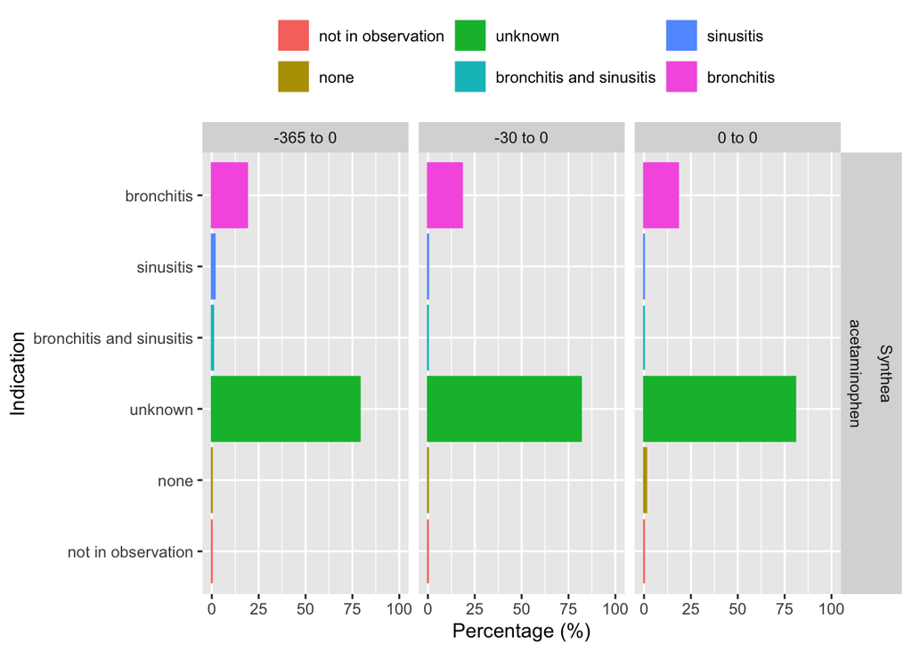

```r
plotIndication(indicationSummary)
```

As well as getting these overall results, we can also stratify the results by some variables of interest. For example, here we stratify our results by age groups and sex.

```r
indicationSummaryStratified <- cdm[["acetaminophen_users"]] |>
  dplyr::select(!dplyr::starts_with("indication")) |>
  PatientProfiles::addDemographics(ageGroup = list(c(0, 19), c(20, 150))) |>
  summariseIndication(
    strata = list("age_group", "sex"),
    indicationCohortName = "indications_cohort",
    indicationWindow = list(c(0, 0), c(-30, 0), c(-365, 0)),
    unknownIndicationTable = c("condition_occurrence")
  )
```

```r
tableIndication(indicationSummaryStratified)
```

| Indication | Estimate name | CDM name Synthea Cohort name acetaminophen Age group overall Sex | CDM name Synthea Cohort name acetaminophen Age group 0 to 19 Sex overall | CDM name Synthea Cohort name acetaminophen Age group 20 to 150 Sex overall | CDM name Synthea Cohort name acetaminophen Age group overall Sex Female | CDM name Synthea Cohort name acetaminophen Age group overall Sex Male |
| --- | --- | --- | --- | --- | --- | --- |
| Indication on index date |  |  |  |  |  |  |
| bronchitis | N (%) | 2,524 (18.16 %) | 1,823 (29.90 %) | 701 (8.98 %) | 1,290 (18.42 %) | 1,234 (17.90 %) |
| sinusitis | N (%) | 1 (0.01 %) | 1 (0.02 %) | 0 (0.00 %) | 0 (0.00 %) | 1 (0.01 %) |
| bronchitis and sinusitis | N (%) | 0 (0.00 %) | 0 (0.00 %) | 0 (0.00 %) | 0 (0.00 %) | 0 (0.00 %) |
| unknown | N (%) | 11,211 (80.66 %) | 4,242 (69.59 %) | 6,969 (89.31 %) | 5,619 (80.23 %) | 5,592 (81.10 %) |
| none | N (%) | 163 (1.17 %) | 30 (0.49 %) | 133 (1.70 %) | 95 (1.36 %) | 68 (0.99 %) |
| not in observation | N (%) | 0 (0.00 %) | 0 (0.00 %) | 0 (0.00 %) | 0 (0.00 %) | 0 (0.00 %) |
| Indication from 30 days before to the index date |  |  |  |  |  |  |
| bronchitis | N (%) | 2,527 (18.18 %) | 1,826 (29.95 %) | 701 (8.98 %) | 1,291 (18.43 %) | 1,236 (17.93 %) |
| sinusitis | N (%) | 18 (0.13 %) | 15 (0.25 %) | 3 (0.04 %) | 11 (0.16 %) | 7 (0.10 %) |
| bronchitis and sinusitis | N (%) | 3 (0.02 %) | 2 (0.03 %) | 1 (0.01 %) | 1 (0.01 %) | 2 (0.03 %) |
| unknown | N (%) | 11,344 (81.62 %) | 4,253 (69.77 %) | 7,091 (90.88 %) | 5,701 (81.40 %) | 5,643 (81.84 %) |
| none | N (%) | 7 (0.05 %) | 0 (0.00 %) | 7 (0.09 %) | 0 (0.00 %) | 7 (0.10 %) |
| not in observation | N (%) | 0 (0.00 %) | 0 (0.00 %) | 0 (0.00 %) | 0 (0.00 %) | 0 (0.00 %) |
| Indication from 365 days before to the index date |  |  |  |  |  |  |
| bronchitis | N (%) | 2,615 (18.81 %) | 1,883 (30.89 %) | 732 (9.38 %) | 1,353 (19.32 %) | 1,262 (18.30 %) |
| sinusitis | N (%) | 211 (1.52 %) | 191 (3.13 %) | 20 (0.26 %) | 108 (1.54 %) | 103 (1.49 %) |
| bronchitis and sinusitis | N (%) | 101 (0.73 %) | 96 (1.57 %) | 5 (0.06 %) | 39 (0.56 %) | 62 (0.90 %) |
| unknown | N (%) | 10,968 (78.91 %) | 3,926 (64.40 %) | 7,042 (90.25 %) | 5,504 (78.58 %) | 5,464 (79.25 %) |
| none | N (%) | 4 (0.03 %) | 0 (0.00 %) | 4 (0.05 %) | 0 (0.00 %) | 4 (0.06 %) |
| not in observation | N (%) | 0 (0.00 %) | 0 (0.00 %) | 0 (0.00 %) | 0 (0.00 %) | 0 (0.00 %) |

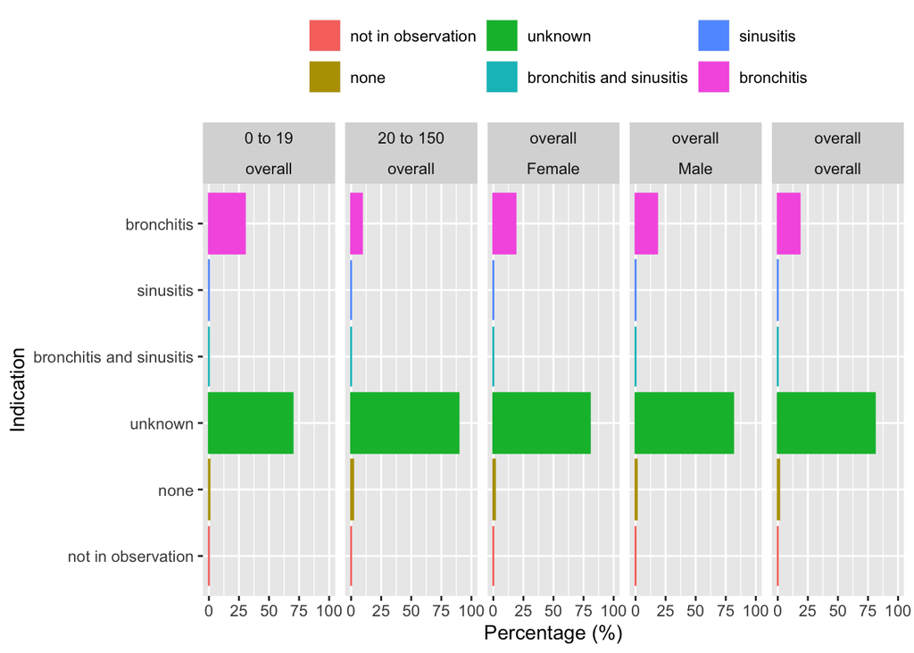

```r
indicationSummaryStratified |>
  dplyr::filter(variable_name == "Indication on index date") |>
  plotIndication(
    facet = . ~ age_group + sex,
    colour = "variable_level"
  )
```